# Exponea AI

### Imports

```python
import pandas as pd
import numpy as np
from sklearn.model_selection import train_test_split
from itertools import combinations
from catboost import Pool, CatBoostClassifier, cv, CatboostIpythonWidget
from sklearn.metrics import confusion_matrix, accuracy_score, f1_score, auc, roc_curve
from sklearn import preprocessing
import pylab
from scipy.cluster.hierarchy import dendrogram, linkage, fcluster
from matplotlib import pyplot as plt
import matplotlib
import operator
```

### Data reading

The file "churn.all.csv" is a small modification of the given file. Features names were added into this file for more comfortable usage. Modified file was attached to the letter.

```python
train_df = pd.read_csv('churn.all.csv')
train_df.head()
```

|  | a | b | c | d | e | f | g | h | i | j | ... | l | m | n | o | p | q | r | s | t | y |
| --- | --- | --- | --- | --- | --- | --- | --- | --- | --- | --- | --- | --- | --- | --- | --- | --- | --- | --- | --- | --- | --- |
| 0 | KS | 128 | 415 | 382-4657 | no | yes | 25 | 265.1 | 110 | 45.07 | ... | 99 | 16.78 | 244.7 | 91 | 11.01 | 10.0 | 3 | 2.70 | 1 | False. |
| 1 | OH | 107 | 415 | 371-7191 | no | yes | 26 | 161.6 | 123 | 27.47 | ... | 103 | 16.62 | 254.4 | 103 | 11.45 | 13.7 | 3 | 3.70 | 1 | False. |
| 2 | NJ | 137 | 415 | 358-1921 | no | no | 0 | 243.4 | 114 | 41.38 | ... | 110 | 10.30 | 162.6 | 104 | 7.32 | 12.2 | 5 | 3.29 | 0 | False. |
| 3 | OH | 84 | 408 | 375-9999 | yes | no | 0 | 299.4 | 71 | 50.90 | ... | 88 | 5.26 | 196.9 | 89 | 8.86 | 6.6 | 7 | 1.78 | 2 | False. |
| 4 | OK | 75 | 415 | 330-6626 | yes | no | 0 | 166.7 | 113 | 28.34 | ... | 122 | 12.61 | 186.9 | 121 | 8.41 | 10.1 | 3 | 2.73 | 3 | False. |

5 rows × 21 columns

### Data preprocessing

Separating features and target. Removeing not informative features, establishing categorical factors (by indexes). Transforming boolean value of y to int value (True = 1 / False = 0).

```python
y = train_df.iloc[:,-1]
y = y.to_frame()
y = y.apply(preprocessing.LabelEncoder().fit_transform)

train_df.drop(train_df.columns[3], axis = 1, inplace = True)
X = train_df.iloc[:,:-1]
cat_features = np.array([0, 3, 4])
```

## Model train

Spliting a train data to train and validation sets.

```python
X_train, X_validation, y_train, y_validation = train_test_split(X, y, train_size=0.5, random_state=1234)
print(X_train.shape, X_validation.shape)
```

```
(2500, 19) (2500, 19)
```

It is important to play with some of model parameters, such as l2_leaf_reg and learning_rate.

### Attention

This block is needed to choose the best options (*l2_leaf_reg*, *learning_rate*) for the model. Counting takes quite a lot of time and requires additional modules. To quickly check the model, you need to skip this block, since the optimal parameters are already pre-defined and are indicated in the models below.

```python
import hyperopt
def hyperopt_objective(params):
    model = CatBoostClassifier(
        l2_leaf_reg=int(params['l2_leaf_reg']),
        learning_rate=params['learning_rate'],
        iterations=500,
        bagging_temperature=1,
        random_strength=1,
        eval_metric='Accuracy',
        use_best_model=True,
        random_seed=42,
        logging_level='Silent'
    )

    cv_data = cv(
        model.get_params(),
        Pool(X, y, cat_features=categorical_features_indices)
    )
    best_accuracy = np.max(cv_data['Accuracy_test_avg'])

    return 1 - best_accuracy

params_space = {
    'l2_leaf_reg': hyperopt.hp.qloguniform('l2_leaf_reg', 0, 2, 1),
    'learning_rate': hyperopt.hp.uniform('learning_rate', 1e-3, 5e-1),
}

trials = hyperopt.Trials()

# todo - uncomment to find the best params.
# best = hyperopt.fmin(
#     hyperopt_objective,
#     space=params_space,
#     algo=hyperopt.tpe.suggest,
#     max_evals=100,
#     trials=trials
# )

# print (best)
```

Create a model with best parameters: *l2_leaf_reg* = 4.0, *learning_rate* = 0.07521709965938336

```python
from catboost import CatBoostClassifier

best_model = CatBoostClassifier(
#     l2_leaf_reg=int(best['l2_leaf_reg']),
#     learning_rate=best['learning_rate'],
    bagging_temperature=1,
    random_strength=1,
    thread_count=3,
    iterations=500,
    l2_leaf_reg = 4.0,
    learning_rate = 0.07521709965938336,
    save_snapshot=True,
    snapshot_file='snapshot_best.bkp',
    random_seed=63,
    od_type='Iter',
    od_wait=20,
    custom_loss=['AUC', 'Accuracy'],
    use_best_model=True
)
best_model.fit(
    X_train, y_train,
    cat_features=cat_features,
    eval_set=(X_validation, y_validation),
    logging_level='Silent',
    plot=True
)
```

```
<catboost.core.CatBoostClassifier at 0x11ebdf7b8>
```

```python
print ('Resulting tree count:', best_model.tree_count_)
```

```
Resulting tree count: 217
```

### Cross Validation

```python
from catboost import cv

params = best_model.get_params()
params['iterations'] = 10
params['custom_loss'] = 'AUC'
del params['use_best_model']
pool1 = Pool(X, label=y, cat_features=cat_features)

cv_data = cv(
    params = params,
    pool = pool1,
    fold_count=2,
    inverted=False,
    shuffle=True,
    stratified=False,
    partition_random_seed=0
)
```

```
0:	learn: 0.6077764	test: 0.6080535	best: 0.6080535 (0)	total: 17.4ms	remaining: 157ms
1:	learn: 0.5490591	test: 0.5506713	best: 0.5506713 (1)	total: 33.9ms	remaining: 136ms
2:	learn: 0.4999740	test: 0.5024443	best: 0.5024443 (2)	total: 52.4ms	remaining: 122ms
3:	learn: 0.4587865	test: 0.4630253	best: 0.4630253 (3)	total: 70.9ms	remaining: 106ms
4:	learn: 0.4233644	test: 0.4279011	best: 0.4279011 (4)	total: 88.6ms	remaining: 88.6ms
5:	learn: 0.3934351	test: 0.3992734	best: 0.3992734 (5)	total: 106ms	remaining: 70.8ms
6:	learn: 0.3697277	test: 0.3759985	best: 0.3759985 (6)	total: 123ms	remaining: 52.6ms
7:	learn: 0.3525423	test: 0.3595001	best: 0.3595001 (7)	total: 137ms	remaining: 34.2ms
8:	learn: 0.3311368	test: 0.3388276	best: 0.3388276 (8)	total: 154ms	remaining: 17.1ms
9:	learn: 0.3142700	test: 0.3233714	best: 0.3233714 (9)	total: 174ms	remaining: 0us
```

```python
best_value = np.max(cv_data['AUC_test_avg'])
best_iter = np.argmax(cv_data['AUC_test_avg'])
print ('Best validation AUC score: {:.2f}±{:.2f} on step {}'.format(
    best_value,
    cv_data['AUC_test_stddev'][best_iter],
    best_iter
))
```

```
Best validation AUC score: 0.91±0.00 on step 9
```

## Bagging

Average predictions from several models trained with different randomseed for the best quality.

```python
from catboost import CatBoostClassifier
from catboost import Pool

predictions = []
for i in range(63):
    clf = CatBoostClassifier(
        one_hot_max_size=(3 + i) % 10,
        bagging_temperature=1,
        random_strength=1,
        thread_count=3,
        iterations=500,
        l2_leaf_reg=4.0,
        learning_rate=0.07521709965938336,
        random_seed=i,
        od_type='Iter',
        od_wait=30,
        custom_loss=['AUC', 'Accuracy'],
        use_best_model=True
    )

    clf.fit(
        X_train,
        y_train,
        cat_features=cat_features,
        eval_set=(X_validation, y_validation),
        logging_level='Silent')

    predictions.append(clf.predict_proba(X_validation)[:,1])
```

Get a prediction like a mean of all predictions.

```python
prediction = np.mean(predictions, axis=0)
```

We will use a trick for the best quality.

```python
bound = 0.25
for i in range(len(prediction)):
    if prediction[i] >= bound:
        prediction[i] = 1
    else :
        prediction[i] = 0
```

Check a validation accuracy score.

```python
print("Accuracy score: ", accuracy_score(y_validation, prediction))
```

```
Accuracy score:  0.9552
```

## Results

### Metrics

Lets check different metrics i.e. *Accuracy*, *Confusion matrix*, *AUC*.

```python
def show_metrics(y_test, y_pred):
    print("Accuracy: " + str(accuracy_score(y_test, y_pred)))
    print("Confusion matrix")
    print(confusion_matrix(y_test, y_pred))
    fpr, tpr, thresholds = roc_curve(y_validation, prediction)
    print("AUC: " + str(auc(fpr, tpr)))

show_metrics(y_validation, prediction)
```

```
Accuracy: 0.9552
Confusion matrix
[[2104   63]
 [  49  284]]
AUC: 0.91189020123
```

### Feature importance

Lets pay attention onto feature importances.

There are sorted features.

```python
importances = best_model.feature_importances_
print ('Feature name : Feature importance')
x = dict(zip(np.array(pool1.get_feature_names()), np.array(importances)))
l = sorted(x.items(), key=operator.itemgetter(1))
for i in range(len(l) - 1, -1, -1):
    print(l[i])
```

```
Feature name : Feature importance
('t', 12.459616072881065)
('e', 11.679638651184717)
('h', 11.515606297372649)
('j', 10.095105880350301)
('r', 7.6855977862842355)
('m', 6.8558925191191058)
('k', 5.6030140943563715)
('p', 4.2384234342845026)
('f', 4.1888887426029289)
('s', 4.1377360659744529)
('q', 4.0111120672609735)
('b', 3.7501350678115628)
('n', 3.2496889388674211)
('g', 2.6290120277281184)
('i', 2.1335898195964003)
('a', 2.023495515329615)
('o', 1.9361925456500368)
('l', 1.5258099305149793)
('c', 0.2814445428305492)
```

### Dendrogram

Lets pay attention onto the dendrogram to find clusters in our data.

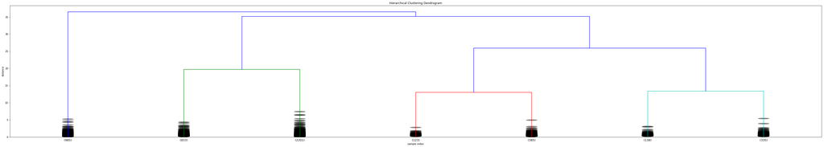

```python
plt.figure(figsize=(60, 10))
plt.title('Hierarchical Clustering Dendrogram')
plt.xlabel('sample index')
plt.ylabel('distance')
X1 = np.copy(X)
df = X.drop(X.columns[[0,3,4]], axis = 1)
df['e'] = preprocessing.LabelEncoder().fit_transform(X['e'])
df['y'] = y

link = linkage(preprocessing.MinMaxScaler().fit_transform(df), 'ward', 'euclidean')

dn = dendrogram(
    link,
    truncate_mode='lastp',
    p=7,
    show_contracted=True,
    )
plt.show()
```

Mean value for the features in the biggest 3 clusters.

```python
df['cluster'] = fcluster(link, 3, criterion='maxclust')
df.groupby('cluster').mean()
```

| cluster | b | c | g | h | i | j | k | l | m | n | o | p | q | r | s | t | e | y |
| --- | --- | --- | --- | --- | --- | --- | --- | --- | --- | --- | --- | --- | --- | --- | --- | --- | --- | --- |
| 1 | 99.207107 | 510.000000 | 8.234518 | 173.354213 | 99.096447 | 29.470721 | 198.959188 | 99.567513 | 16.911807 | 200.321827 | 100.515736 | 9.014558 | 10.195127 | 4.361421 | 2.753076 | 1.519797 | 0.000000 | 0.000000 |
| 2 | 99.997693 | 412.653593 | 8.230059 | 176.184542 | 100.036915 | 29.951955 | 198.403527 | 100.334542 | 16.864515 | 199.529367 | 99.728741 | 8.978949 | 10.225972 | 4.477917 | 2.761572 | 1.446935 | 0.000000 | 0.000000 |
| 3 | 102.121305 | 438.548420 | 5.805301 | 199.945668 | 100.942915 | 33.991284 | 209.227013 | 100.373089 | 17.784444 | 203.128440 | 99.909276 | 9.140866 | 10.439450 | 4.377166 | 2.819154 | 2.003058 | 0.482161 | 0.720693 |

As we can see, one of the clusters (**cluster 3**) with an average target value close to unity, the other two close to zero. We can look at the characteristics in which there is a strong difference. We can observe that the value of the feature with the name *e* for **cluster 3** is very different from the value for **clusters 1** and **2**, with the taggts at zero. A similar situation we can observe for features *t*, *h*, that confirms the aformentioned features importance data.

### Histogram

For a more visual presentation, one can give few histograms.

Histogram for feature *e*

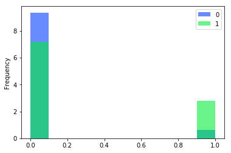

```python
matplotlib.style.use('seaborn-bright')
%matplotlib inline
df.groupby('y')['e'].plot.hist(normed=1, alpha=0.6)
plt.legend()
```

Histogram for feature *t*

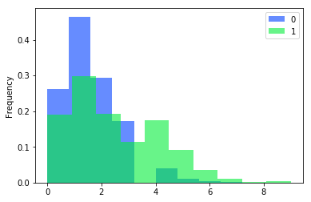

```python
%matplotlib inline
df.groupby('y')['t'].plot.hist(normed=1, alpha=0.6)
plt.legend()
```

### Diagram

There is a diagram describing the ratio of a target with a value of true to the entire data set.

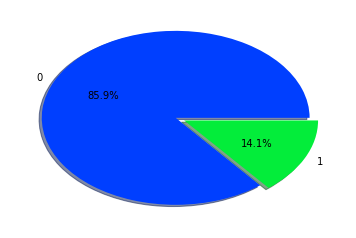

```python
labels = ["0", "1"]
explode = [0.02, 0.05]
y1 = np.asarray(y, dtype=int)
unique, counts = np.unique(y1, return_counts=True)
plt = pylab.pie (counts,  explode=explode, labels=labels, shadow=True, autopct='%1.1f%%')
pylab.show()
```

As we see the data are heterogeneous, this affects the quality of the model.

## Summary

> What affects the churn?
- In order to understand what factors most strongly affects the churn, you can look at the feature importance and the mean value of factors in clustering data.
- Comparing these indicators, one can come to the conclusion that the characteristic of the *international plan* is most strongly seen, then the *number customer service calls*, then the *total day minutes*, and, finally, the *total day charge*. The other characteristics have less impact on the result.

> What affected the quality of the model?

Most of all, the inaccuracy of the prediction is affected by the heterogeneity of the data.

- In the provided data set, a strong predominance of examples with the result *False* (86%) is observed as we can see on the diagram above.
- Data was not normalized, that is, different features have different weights at the input, not relying on their importance.

## Recomendation

> Based on the model built, I would recommend paying close attention to the *number customer service calls* and the *international plan*.
- The presence of an *international plan* (that is, the value of *yes*) often coincides with the value of the target *True*. That is, you can trace the pattern based on this characteristic. The same applies to *number customer service calls*. Accordingly, changing the values of these features and possibly several more important features of the model, you can change the result